# Is there structural inconsistency in human rights performance across countries? How are these inconsistencies related to gender and intra-group inequality

We want to explore structural misalignments in global human rights

## Insight 1: Mismatch Between Civil and Political Rights and Basic Needs

### Q: Are there countries that do well in civil and political rights—like protecting freedom and safety—but perform poorly in basic needs like health, education, or housing? Has this mismatch gotten better or worse between 2017 and 2023?

#### Python Package Imports Explanation

The following imports are used for data analysis, visualization, and machine learning tasks:

##### Core Data Handling

- **`pandas as pd`**: Primary package for data manipulation and analysis with DataFrames
- **`numpy as np`**: Fundamental package for numerical computing and array operations

#### Data Visualization

- **`matplotlib.pyplot as plt`**: Foundational plotting library for creating static, interactive, and animated visualizations
- **`seaborn as sns`**: High-level visualization library built on matplotlib for statistical graphics

#### Statistical Analysis

- **`statsmodels.api as sm`**: Provides classes and functions for estimating statistical models and conducting statistical tests
- **`scipy.stats`**: Contains a wide range of probability distributions and statistical functions

#### Machine Learning & Dimensionality Reduction

- **`StandardScaler`**: For standardizing features by removing the mean and scaling to unit variance
- **`PCA`**: Principal Component Analysis for dimensionality reduction
- **`KMeans`**: K-Means clustering algorithm for unsupervised machine learning

#### Package Installation

- **`%pip install scipy scikit-learn`**: Installs required packages (scipy for scientific computing and scikit-learn for machine learning) if not already present

```python
import pandas as pd
import numpy as np
import matplotlib.pyplot as plt
import seaborn as sns
import statsmodels.api as sm
%pip install scipy scikit-learn
from scipy import stats
from sklearn.preprocessing import StandardScaler
from sklearn.decomposition import PCA
from sklearn.cluster import KMeans
```

##### We begin by importing several datasets from the Human Rights Measurement Initiative (HRMI)

- including: Civil and political rights (CPR) scores, Economic and social rights (ESR) scores, adjusted for income levels, Disaggregated ESR data by sex, and Data on people at risk

```python
# Load Datasets
cpr = pd.read_csv("/Users/yanglyu/Downloads/HRMI_Data_Download_2024_release 2/HRMI_Data_Download_2024.6.20/csv files/cpr.csv", encoding='latin1')
esr_lmy = pd.read_csv('/Users/yanglyu/Downloads/HRMI_Data_Download_2024_release 2/HRMI_Data_Download_2024.6.20/csv files/esr_lmy_incomeadjusted.csv')
esr_hiy = pd.read_csv('/Users/yanglyu/Downloads/HRMI_Data_Download_2024_release 2/HRMI_Data_Download_2024.6.20/csv files/esr_hiy_incomeadjusted.csv')
esr_sex = pd.read_csv('/Users/yanglyu/Downloads/HRMI_Data_Download_2024_release 2/HRMI_Data_Download_2024.6.20/csv files/esr_sex_disaggregated.csv')
people_risk = pd.read_csv('/Users/yanglyu/Downloads/HRMI_Data_Download_2024_release 2/HRMI_Data_Download_2024.6.20/csv files/people_at_risk.csv')
```

### 1. Identifying the "Rights Paradox": Countries Strong in Freedoms but Weak in Basic Needs

In this section, we process and integrate data on Civil and Political Rights (CPR) and Economic and Social Rights (ESR) to identify a phenomenon referred to as the **"Rights Paradox"**—where countries perform strongly in civil liberties but poorly in basic social and economic provisions.

First, we calculate an overall CPR score by averaging the existing *physical integrity* and *empowerment* scores from the dataset. For ESR, I compute a score separately for low/middle-income and high-income countries by averaging five core indicators: **education**, **food**, **health**, **housing**, and **work**. These ESR scores are then combined and merged with the CPR scores by matching countries and years.

Next, we calculate the **rights gap** as the difference between the CPR and ESR scores. To identify paradoxical cases, we define countries in the top 25% of CPR scores and bottom 25% of ESR scores as exhibiting this mismatch. These are the countries where people may enjoy strong protections of freedom and safety, yet lack access to fundamental needs like healthcare or education.

Finally, we output a list of the top countries with the largest rights gaps to spotlight the most extreme instances of this paradox.

```python
# Process CPR data - calculate overall civil and political rights score
# physint (physical integrity) and empower (empowerment) are already computed in the dataset
cpr['cpr_score'] = cpr[['physint_mean', 'empower_mean']].mean(axis=1)

# Process ESR data
# For low and middle income countries
esr_lmy['esr_score'] = esr_lmy[['LMY_Education_All_IAScore',
                                      'LMY_Food_All_IAScore',
                                      'LMY_Health_All_IAScore',
                                      'LMY_Housing_All_IAScore',
                                      'LMY_Work_All_IAScore']].mean(axis=1)


# For high income countries
esr_hiy['esr_score'] = esr_hiy[['HiY_Education_All_IAScore',
                                      'HiY_Food_All_IAScore',
                                      'HiY_Health_All_IAScore',
                                      'HiY_Housing_All_IAScore',
                                      'HiY_Work_All_IAScore']].mean(axis=1)

# Merge datasets based on high income flag
esr_lmy_subset = esr_lmy[esr_lmy['High_Income_Country'] == 0][['Country', 'Year', 'esr_score']]
esr_hiy_subset = esr_hiy[esr_hiy['High_Income_Country'] == 1][['Country', 'Year', 'esr_score']]
esr_combined = pd.concat([esr_lmy_subset, esr_hiy_subset])

# Merge CPR and ESR datasets
rights_df = pd.merge(cpr[['country', 'year', 'cpr_score']],
                    esr_combined,
                    left_on=['country', 'year'],
                    right_on=['Country', 'Year'],
                    how='inner')

# Calculate the difference between CPR and ESR scores
rights_df['rights_gap'] = rights_df['cpr_score'] - rights_df['esr_score']

# Identify countries with high CPR but low ESR (the paradox)
# Define high CPR as above 75th percentile and low ESR as below 25th percentile
high_cpr_threshold = rights_df['cpr_score'].quantile(0.75)
low_esr_threshold = rights_df['esr_score'].quantile(0.25)

paradox_countries = rights_df[(rights_df['cpr_score'] >= high_cpr_threshold) &
                            (rights_df['esr_score'] <= low_esr_threshold)]

# Display the countries with this paradox
print(f"Number of country-years with 'Rights Paradox': {len(paradox_countries)}")
paradox_display = paradox_countries[['country', 'year', 'cpr_score', 'esr_score', 'rights_gap']].sort_values('rights_gap', ascending=False)
paradox_display.head(10)
```

```
Number of country-years with 'Rights Paradox': 1
```

|  | country | year | cpr_score | esr_score | rights_gap |
| --- | --- | --- | --- | --- | --- |
| 25 | Liberia | 2017 | 7.507464 | 65.91989 | -58.412426 |

### 2. Visualizing the Relationship Between Civil and Political Rights and Economic and Social Rights

In this section, we create a scatter plot to visualize the relationship between Civil and Political Rights (CPR) scores and Economic and Social Rights (ESR) scores for various countries over time. Each point represents a country-year observation, and the color intensity reflects the "rights gap"—the difference between CPR and ESR scores—using a color scale.

We also overlay a green dashed regression line to show the overall trend between CPR and ESR. Countries identified as exhibiting a “rights paradox” (high CPR but low ESR) are highlighted in yellow with black edges, and their names and years are labeled directly on the plot.

To help interpret this paradox further, we also draw dashed lines to indicate the thresholds used for "high CPR" and "low ESR". Finally, we calculate and print the Pearson correlation coefficient between CPR and ESR scores to quantify the overall relationship between the two rights dimensions.

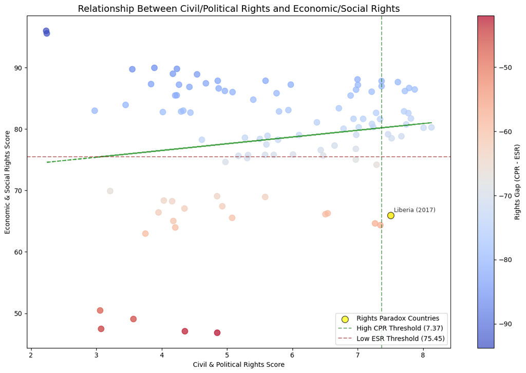

```
Correlation between CPR and ESR scores: 0.163
```

```python
plt.figure(figsize=(12, 8))
scatter = plt.scatter(rights_df['cpr_score'], rights_df['esr_score'],
                      c=rights_df['rights_gap'], cmap='coolwarm',
                      alpha=0.7, s=80)

# Add regression line
x = rights_df['cpr_score']
y = rights_df['esr_score']

# Remove rows with NaN or Inf values
valid_data = rights_df.dropna(subset=['cpr_score', 'esr_score'])
x = valid_data['cpr_score']
y = valid_data['esr_score']

m, b = np.polyfit(x, y, 1)
plt.plot(x, m*x + b, 'g--', alpha=0.7)

# Highlight paradox countries
plt.scatter(paradox_countries['cpr_score'], paradox_countries['esr_score'],
            color='yellow', s=100, edgecolor='black', alpha=0.7,
            label='Rights Paradox Countries')

# Add country labels for paradox countries
for i, row in paradox_countries.iterrows():
    plt.annotate(f"{row['country']} ({row['year']})",
                 (row['cpr_score'], row['esr_score']),
                 xytext=(5, 5), textcoords='offset points',
                 fontsize=9, alpha=0.8)

# Add lines to show the thresholds
plt.axvline(x=high_cpr_threshold, color='darkgreen', linestyle='--', alpha=0.5,
            label=f'High CPR Threshold ({high_cpr_threshold:.2f})')
plt.axhline(y=low_esr_threshold, color='darkred', linestyle='--', alpha=0.5,
            label=f'Low ESR Threshold ({low_esr_threshold:.2f})')

plt.colorbar(scatter, label='Rights Gap (CPR - ESR)')
plt.xlabel('Civil & Political Rights Score')
plt.ylabel('Economic & Social Rights Score')
plt.title('Relationship Between Civil/Political Rights and Economic/Social Rights', fontsize=14)
plt.legend(loc='lower right')
plt.tight_layout()
plt.show()

# Calculate correlation
correlation = rights_df['cpr_score'].corr(rights_df['esr_score'])
print(f"Correlation between CPR and ESR scores: {correlation:.3f}")
```

First, we calculate the average rights gap for each year by grouping the dataset by year and computing the mean difference between CPR and ESR scores. Then, we create a line plot to visualize the yearly trend of this gap. To help identify the overall direction of change, we fit a linear regression line to the plot. This red dashed trendline indicates whether the gap is increasing or decreasing over time, providing insights into whether countries are becoming more or less balanced in their protection of both types of rights.

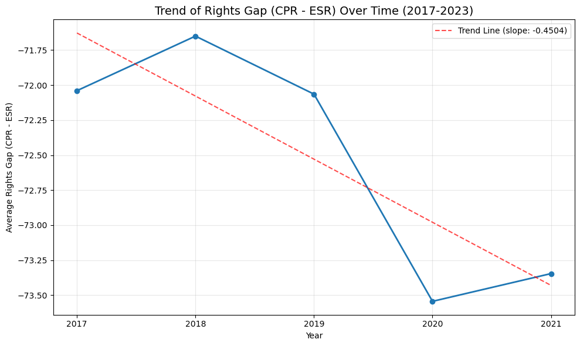

```python
# Calculate average rights gap by year
yearly_gap = rights_df.groupby('year')['rights_gap'].mean().reset_index()

# Plot the trend of rights gap over time
plt.figure(figsize=(10, 6))
plt.plot(yearly_gap['year'], yearly_gap['rights_gap'], marker='o', linewidth=2)
plt.xlabel('Year')
plt.ylabel('Average Rights Gap (CPR - ESR)')
plt.title('Trend of Rights Gap (CPR - ESR) Over Time (2017-2023)', fontsize=14)
plt.grid(True, alpha=0.3)
plt.xticks(yearly_gap['year'])

# Add linear trendline
x = yearly_gap['year']
y = yearly_gap['rights_gap']
z = np.polyfit(x, y, 1)
p = np.poly1d(z)
plt.plot(x, p(x), "r--", alpha=0.7, label=f"Trend Line (slope: {z[0]:.4f})")
plt.legend()
plt.tight_layout()
plt.show()
```

## Insight 2: Structural Typology of Human Rights

### Q: Can countries be systematically classified into distinct structural profiles of human rights performance—based on CPR, ESR, gender disparities, and group-specific vulnerabilities? What patterns emerge?

We will three sets of indicators to explore human rights performance across countries:

- **CPR Score (Civil and Political Rights)**: Average of empowerment and physical integrity scores.
- **ESR Score (Economic and Social Rights)**: Average achievement in rights to health, education, housing, work, and food.
- **Group Risk**: Proportion of marginalized groups (e.g., LGBTQ+, women, immigrants) facing elevated risk in freedom of expression and related areas.

Using data from 2017 to 2023, we applied PCA and KMeans clustering to classify countries into distinct human rights structures based on these indicators.

First, we integrates data from three sources (cpr, esr_combined, and people_risk) to create a unified dataset for analysis, which can be used for further statistical or machine learning tasks.

```python
people_risk = people_risk[people_risk['year'].between(2017, 2023)]

# Combine cpr + esr_combined + people_risk
full_data = pd.merge(
    cpr[['country', 'year', 'cpr_score']],
    esr_combined[['Country', 'Year', 'esr_score']],
    left_on=['country', 'year'],
    right_on=['Country', 'Year'],
    how='inner'
)

full_data = pd.merge(
    full_data,
    people_risk[['country', 'year', 'express_atrisk_prop10', 'express_atrisk_prop11', 'express_atrisk_prop24']],
    on=['country', 'year'],
    how='left'
)

# Average group risk
full_data['group_risk'] = full_data[['express_atrisk_prop10', 'express_atrisk_prop11', 'express_atrisk_prop24']].mean(axis=1)

print("Full merged dataset shape:", full_data.shape)
full_data.head()
```

```
Full merged dataset shape: (130, 10)
```

|  | country | year | cpr_score | Country | Year | esr_score | express_atrisk_prop10 | express_atrisk_prop11 | express_atrisk_prop24 | group_risk |
| --- | --- | --- | --- | --- | --- | --- | --- | --- | --- | --- |
| 0 | Angola | 2017 | 3.568726 | Angola | 2017 | 49.066810 | NaN | NaN | NaN | NaN |
| 1 | Angola | 2018 | 4.851679 | Angola | 2018 | 46.829587 | 0.083333 | 0.083333 | 0.416667 | 0.194444 |
| 2 | Angola | 2019 | 4.356458 | Angola | 2019 | 47.077513 | 0.125000 | 0.062500 | 0.375000 | 0.187500 |
| 3 | Angola | 2020 | 3.074039 | Angola | 2020 | 47.461126 | 0.133333 | 0.200000 | 0.133333 | 0.155556 |
| 4 | Angola | 2021 | 3.059052 | Angola | 2021 | 50.457817 | 0.071429 | 0.000000 | 0.142857 | 0.071429 |

### Summary of Clustering Data

We then prepare a subset of the dataset for clustering analysis by focusing on three specific features: `cpr_score`, `esr_score`, and `group_risk`.

To ensure that the clustering algorithm treats all features equally—especially since they may have different units or scales—the data is standardized using `StandardScaler` from scikit-learn. This scaling transforms each feature to have a mean of 0 and a standard deviation of 1, which is confirmed by printing the mean and standard deviation after scaling.

This preprocessing step is critical to avoid bias in clustering results due to feature scale differences.

```python
# Cluster data
cluster_data = full_data[['cpr_score', 'esr_score', 'group_risk']].dropna()

scaler = StandardScaler()
scaled_cluster_data = scaler.fit_transform(cluster_data)

print("Mean after scaling:", scaled_cluster_data.mean(axis=0))
print("Std after scaling:", scaled_cluster_data.std(axis=0))
```

```
Mean after scaling: [ 2.14835365e-16 -1.73021770e-16 -1.15347847e-17]
Std after scaling: [1. 1. 1.]
```

```python
# PCA reduction
pca = PCA(n_components=2)
pca_result = pca.fit_transform(scaled_cluster_data)

print("Explained variance ratio by PCA:", pca.explained_variance_ratio_)


# KMeans, we set 4 categories
kmeans = KMeans(n_clusters=4, random_state=42)
clusters = kmeans.fit_predict(scaled_cluster_data)

cluster_df = cluster_data.reset_index(drop=True)
cluster_df['cluster'] = clusters

# Check the result for clusters
print("Cluster distribution:\n", cluster_df['cluster'].value_counts())


cluster_means = cluster_df.groupby('cluster')[['cpr_score', 'esr_score', 'group_risk']].mean()
cluster_means['group_risk_pct'] = cluster_means['group_risk'] * 100
print(cluster_means)
```

```
Explained variance ratio by PCA: [0.49313212 0.3004813 ]
Cluster distribution:
 cluster
1    29
3    22
0    15
2    11
Name: count, dtype: int64
         cpr_score  esr_score  group_risk  group_risk_pct
cluster
0         4.671307  61.691182    0.171752       17.175215
1         7.244120  81.258268    0.070031        7.003126
2         5.307356  82.364688    0.275724       27.572442
3         4.704660  83.285969    0.123099       12.309890
```

## Interpretation of Clustering Results

Based on PCA and KMeans, we found **four different types of human rights structures** across countries.

Here is a summary:

| Cluster | Name | Human Rights Situation | Social Risk Situation |
| --- | --- | --- | --- |
| **0** | **Moderate Economy, Weak Freedoms** | Medium ESR scores, lower CPR scores | Medium group risk |
| **1** | **Strong All-around Rights** | High CPR and high ESR scores | Very low group risk |
| **2** | **Rich but Divided** | High ESR scores, medium CPR scores | Very high group risk |
| **3** | **Good Economy, Limited Freedoms** | High ESR scores, lower CPR scores | Low-to-medium group risk |

- **Cluster 1** shows countries that do very well in both freedoms and basic needs, with few risks for minority groups.
- **Cluster 2** shows that even though people have good health, education, and housing, minority groups still face big problems.
- **Cluster 0** and **Cluster 3** have lower civil and political rights. Cluster 3 has better basic needs protection (ESR) than Cluster 0.

Overall, we can see that **civil rights, basic needs, and fairness for all groups don't always go together**. Some countries are strong in all areas, but many have imbalances that need attention.

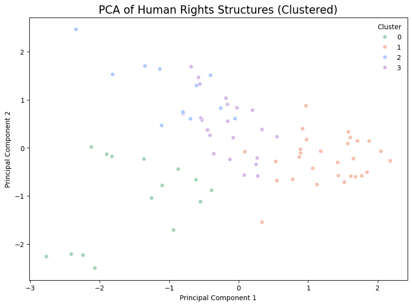

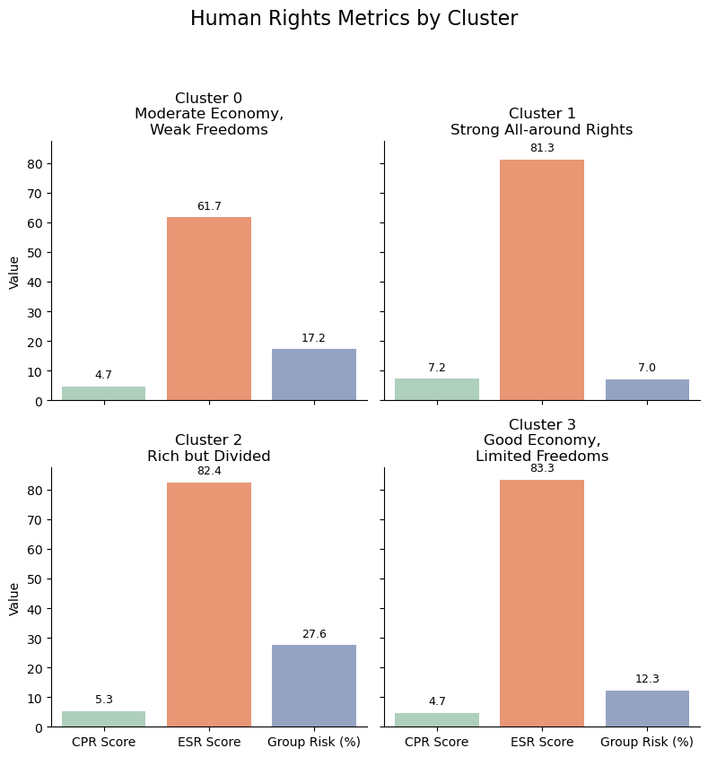

```python
# PCA Plot
plt.figure(figsize=(10,7))
sns.scatterplot(
    x=pca_result[:,0],
    y=pca_result[:,1],
    hue=clusters,
    palette=['#A8D5BA', '#F6C1B0', '#AFCBFF', '#D7BCE8']
)
plt.title("PCA of Human Rights Structures (Clustered)", fontsize=16)
plt.xlabel("Principal Component 1")
plt.ylabel("Principal Component 2")
legend = plt.legend(title="Cluster")
legend.get_frame().set_linewidth(0)
legend.get_frame().set_facecolor('none')
plt.show()

# Clustered Group Risk Plot
bar_df = cluster_means[['cpr_score', 'esr_score', 'group_risk_pct']].reset_index().melt(
    id_vars='cluster',
    value_vars=['cpr_score', 'esr_score', 'group_risk_pct'],
    var_name='metric',
    value_name='value'
)

metric_names = {
    'cpr_score': 'CPR Score',
    'esr_score': 'ESR Score',
    'group_risk_pct': 'Group Risk (%)'
}
bar_df['metric'] = bar_df['metric'].replace(metric_names)

g = sns.catplot(
    data=bar_df,
    x='metric',
    y='value',
    col='cluster',
    kind='bar',
    col_wrap=2,
    height=4,
    aspect=1,
    palette=['#A8D5BA', '#FC8D62', '#8DA0CB']
)

title_mapping = {
    0: "Moderate Economy,\nWeak Freedoms",
    1: "Strong All-around Rights",
    2: "Rich but Divided",
    3: "Good Economy,\nLimited Freedoms"
}

for ax in g.axes.flat:
    cluster_num = int(ax.get_title().split()[-1])
    ax.set_title(f"Cluster {cluster_num}\n{title_mapping[cluster_num]}", fontsize=12)

g.set_axis_labels("", "Value")
for ax in g.axes.flat:
    for bar in ax.patches:
        height = bar.get_height()
        ax.text(
            bar.get_x() + bar.get_width() / 2,
            height + 2,
            f'{height:.1f}',
            ha='center', va='bottom', fontsize=9
        )
plt.suptitle("Human Rights Metrics by Cluster", fontsize=16, y=1.05)
plt.tight_layout()
plt.show()
```

### Insight 2 supplementary question: Gender Gap across Clusters (Education Only)

Now we separately analyzed gender differences in economic and social rights (ESR) since gender-disaggregated ESR scores are only available for 2019.

The gender gap is calculated as the female ESR education score minus the male ESR education score.

A positive value means females perform better in education-related rights; a negative value means males perform better.

```
Merged dataset shape: (31, 13)
```

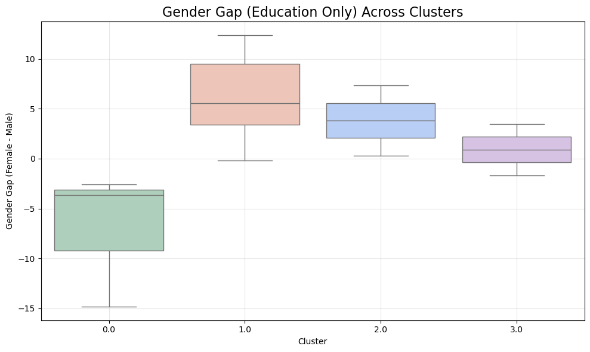

```
   cluster  gender_gap
0      0.0   -7.013213
1      1.0    6.239060
2      2.0    3.831960
3      3.0    0.909247
```

```python
esr_sex_2019 = esr_sex[esr_sex['Year'] == 2019].copy()

# For high-income countries（High_Income_Country == 1）
esr_sex_2019_hi = esr_sex_2019[esr_sex_2019['High_Income_Country'] == 1].copy()
esr_sex_2019_hi['gender_gap'] = esr_sex_2019_hi['HiY_Education_Female_IAScore'] - esr_sex_2019_hi['HiY_Education_Male_IAScore']

# Low/middle-income countries（High_Income_Country == 0）
esr_sex_2019_lmy = esr_sex_2019[esr_sex_2019['High_Income_Country'] == 0].copy()
esr_sex_2019_lmy['gender_gap'] = esr_sex_2019_lmy['LMY_Education_Female_IAScore'] - esr_sex_2019_lmy['LMY_Education_Male_IAScore']

esr_sex_2019_final = pd.concat([esr_sex_2019_hi, esr_sex_2019_lmy])
gender_gap_data = esr_sex_2019_final[['Country', 'gender_gap']].copy()


full_data_with_cluster = pd.merge(
    full_data,
    cluster_df[['cpr_score', 'esr_score', 'group_risk', 'cluster']],
    left_on=['cpr_score', 'esr_score', 'group_risk'],
    right_on=['cpr_score', 'esr_score', 'group_risk'],
    how='left'
)

# data for 2019
full_data_2019 = full_data_with_cluster[full_data_with_cluster['year'] == 2019].copy()

# Merge gender gap
merged_gender_cluster = pd.merge(
    full_data_2019,
    gender_gap_data,
    left_on='country',
    right_on='Country',
    how='left'
)
print("Merged dataset shape:", merged_gender_cluster.shape)
merged_gender_cluster[['country', 'cluster', 'gender_gap']].head()

plt.figure(figsize=(10,6))
sns.boxplot(
    data=merged_gender_cluster,
    x='cluster',
    y='gender_gap',
    palette=['#A8D5BA', '#F6C1B0', '#AFCBFF', '#D7BCE8']
)
plt.title('Gender Gap (Education Only) Across Clusters', fontsize=16)
plt.xlabel('Cluster')
plt.ylabel('Gender Gap (Female - Male)')
plt.grid(alpha=0.3)
plt.tight_layout()
plt.show()

# Gender gap mean for each cluster
gender_gap_summary = merged_gender_cluster.groupby('cluster')['gender_gap'].mean().reset_index()
print(gender_gap_summary)
```

### Observations: Gender Gap (Education Only) Across Clusters

#### Key Findings:

1. **Cluster 1 (Strong All-around Rights)** shows the largest **positive gender gap (+6.24)**, indicating:
   - Female education scores significantly outperform male scores
   - Suggests successful gender parity policies in education
2. **Cluster 2 (Rich but Divided)** maintains a moderate **positive gap (+3.83)**:
   - Continues the trend of female educational advantage
   - Smaller gap than Cluster 1 may reflect inequality in resource distribution
3. **Cluster 3 (Good Economy, Limited Freedoms)** shows near-parity **(+0.91)**:
   - Minimal gender difference in education
   - May indicate restrictive policies affecting both genders equally
4. **Cluster 0 (Moderate Economy, Weak Freedoms)** has a **negative gap (-7.01)**:
   - Male education scores substantially exceed female scores
   - Reveals significant gender inequality in educational access

#### Interpretation:

- The gender gap strongly correlates with cluster characteristics:
  - Rights-protective clusters (1-2) show female educational advantage
  - Economically-focused clusters (0,3) show either male advantage or parity
- Economic strength alone (Cluster 2 vs 3) doesn't guarantee gender equality
- Weak freedoms (Cluster 0) correlate most strongly with female educational disadvantage

## Insight 3: Linking Structural Misalignment to Internal Inequality

### Q: Among countries identified as structurally misaligned in Insight 1 and clustered into distinct profiles in Insight 2, how are alignment scores associated with internal inequality measures？

In this analysis, we investigate how structural misalignment between civil/political rights (CPR) and economic/social rights (ESR) - identified in Insight 1 - relates to internal inequality measures across our clustered country profiles from Insight 2. Using regression analysis and visual exploration.

First, we create two graphs comparing rights gaps against both gender gaps in education (left graph) and group risk percentages (right graph), with countries color-coded by their cluster membership and overlaid with overall regression trends. Second, we perform cluster-specific regression analyses to quantify how these inequality measures predict rights gaps within each distinct country profile, reporting coefficients, statistical significance, and model fit metrics for each cluster. The visualizations highlight patterns across all countries while preserving cluster distinctions, while the regression outputs provide detailed insights into how different types of inequality correlate with rights misalignment.

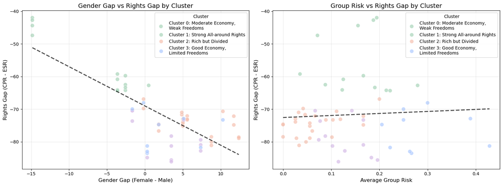

```
=== Cluster-Specific Regression Analysis ===

--- Moderate Economy,
Weak Freedoms (Cluster 0) ---
Countries: 13
Gender Gap Coef: -1.472 (p=0.000)
Group Risk Coef: 8.996 (p=0.440)
R-squared: 0.930

--- Strong All-around Rights (Cluster 1) ---
Countries: 24
Gender Gap Coef: -0.579 (p=0.000)
Group Risk Coef: 35.256 (p=0.001)
R-squared: 0.589

Cluster 2 has insufficient data for regression analysis

--- Good Economy,
Limited Freedoms (Cluster 3) ---
Countries: 12
Gender Gap Coef: -0.725 (p=0.136)
Group Risk Coef: -40.868 (p=0.264)
R-squared: 0.356
```

```python
# 1. Add cluster information to regression data
merged_data['cluster'] = merged_data['cluster'].astype('category')

# 2. Enhanced visualization showing clusters in regression plots
plt.figure(figsize=(16, 6))

# Subplot 1: Gender Gap vs Alignment Score with clusters
ax1 = plt.subplot(1, 2, 1)
sns.scatterplot(
    x=regression_data['gender_gap'],
    y=regression_data['rights_gap'],
    hue=merged_data.loc[regression_data.index, 'cluster'],
    palette=['#A8D5BA', '#F6C1B0', '#AFCBFF', '#D7BCE8'],
    alpha=0.7,
    s=80
)

# Add regression line for all data
sns.regplot(
    x=regression_data['gender_gap'],
    y=regression_data['rights_gap'],
    scatter=False,
    line_kws={'color': 'black', 'linestyle': '--', 'alpha': 0.7},
    ci=None,
    ax=ax1
)

plt.title('Gender Gap vs Rights Gap by Cluster', fontsize=14)
plt.xlabel('Gender Gap (Female - Male)', fontsize=12)
plt.ylabel('Rights Gap (CPR - ESR)', fontsize=12)
plt.legend(title='Cluster', labels=[f'Cluster {i}: {title_mapping[i]}' for i in range(4)])
plt.grid(alpha=0.3)

# Subplot 2: Group Risk vs Alignment Score with clusters
ax2 = plt.subplot(1, 2, 2)
sns.scatterplot(
    x=regression_data['avg_group_risk'],
    y=regression_data['rights_gap'],
    hue=merged_data.loc[regression_data.index, 'cluster'],
    palette=['#A8D5BA', '#F6C1B0', '#AFCBFF', '#D7BCE8'],
    alpha=0.7,
    s=80
)

# Add regression line for all data
sns.regplot(
    x=regression_data['avg_group_risk'],
    y=regression_data['rights_gap'],
    scatter=False,
    line_kws={'color': 'black', 'linestyle': '--', 'alpha': 0.7},
    ci=None,
    ax=ax2
)

plt.title('Group Risk vs Rights Gap by Cluster', fontsize=14)
plt.xlabel('Average Group Risk', fontsize=12)
plt.ylabel('Rights Gap (CPR - ESR)', fontsize=12)
plt.legend(title='Cluster', labels=[f'Cluster {i}: {title_mapping[i]}' for i in range(4)])
plt.grid(alpha=0.3)

plt.tight_layout()
plt.show()

# 3. Cluster-specific regression analysis
print("\n=== Cluster-Specific Regression Analysis ===")
for cluster_num in range(4):
    cluster_mask = (merged_data['cluster'] == cluster_num) & (~regression_data['gender_gap'].isna())
    cluster_reg_data = regression_data[cluster_mask]

    if len(cluster_reg_data) > 10:  # Only run if sufficient data points
        X_cluster = sm.add_constant(cluster_reg_data[['gender_gap', 'avg_group_risk']])
        y_cluster = cluster_reg_data['rights_gap']

        model_cluster = sm.OLS(y_cluster, X_cluster).fit()

        print(f"\n--- {title_mapping[cluster_num]} (Cluster {cluster_num}) ---")
        print(f"Countries: {len(cluster_reg_data)}")
        print(f"Gender Gap Coef: {model_cluster.params['gender_gap']:.3f} (p={model_cluster.pvalues['gender_gap']:.3f})")
        print(f"Group Risk Coef: {model_cluster.params['avg_group_risk']:.3f} (p={model_cluster.pvalues['avg_group_risk']:.3f})")
        print(f"R-squared: {model_cluster.rsquared:.3f}")
    else:
        print(f"\nCluster {cluster_num} has insufficient data for regression analysis")
```

### Introduction to Regression Analysis

Then, we will examine how internal inequality measures relate to structural misalignment between civil/political rights (CPR) and economic/social rights (ESR).

```python
# Add the non-duplicated regression analysis from additional code
# Define independent variables (inequality measures) and dependent variable (alignment score)
X = regression_data[['gender_gap', 'avg_group_risk']]
y = regression_data['rights_gap']

# Add a constant for the regression model
X = sm.add_constant(X)

# Fit the linear regression model
model = sm.OLS(y, X).fit()

# Print the regression summary
print("\n=== Overall Regression Analysis ===")
print(model.summary())

# 3. Cluster-specific regression analysis
print("\n=== Cluster-Specific Regression Analysis ===")
for cluster_num in range(4):
    cluster_mask = (merged_data['cluster'] == cluster_num) & (~regression_data['gender_gap'].isna())
    cluster_reg_data = regression_data[cluster_mask]

    if len(cluster_reg_data) > 10:  # Only run if sufficient data points
        X_cluster = sm.add_constant(cluster_reg_data[['gender_gap', 'avg_group_risk']])
        y_cluster = cluster_reg_data['rights_gap']

        model_cluster = sm.OLS(y_cluster, X_cluster).fit()

        print(f"\n--- {title_mapping[cluster_num]} (Cluster {cluster_num}) ---")
        print(f"Countries: {len(cluster_reg_data)}")
        print(f"Gender Gap Coef: {model_cluster.params['gender_gap']:.3f} (p={model_cluster.pvalues['gender_gap']:.3f})")
        print(f"Group Risk Coef: {model_cluster.params['avg_group_risk']:.3f} (p={model_cluster.pvalues['avg_group_risk']:.3f})")
        print(f"R-squared: {model_cluster.rsquared:.3f}")
    else:
        print(f"\nCluster {cluster_num} has insufficient data for regression analysis")
```

```
=== Overall Regression Analysis ===
                            OLS Regression Results
==============================================================================
Dep. Variable:             rights_gap   R-squared:                       0.622
Model:                            OLS   Adj. R-squared:                  0.608
Method:                 Least Squares   F-statistic:                     45.16
Date:                Thu, 01 May 2025   Prob (F-statistic):           2.49e-12
Time:                        19:18:49   Log-Likelihood:                -187.74
No. Observations:                  58   AIC:                             381.5
Df Residuals:                      55   BIC:                             387.7
Df Model:                           2
Covariance Type:            nonrobust
==================================================================================
                     coef    std err          t      P>|t|      [0.025      0.975]
----------------------------------------------------------------------------------
const            -67.4212      1.543    -43.683      0.000     -70.514     -64.328
gender_gap        -1.2351      0.130     -9.478      0.000      -1.496      -0.974
avg_group_risk   -11.2518      9.029     -1.246      0.218     -29.347       6.843
==============================================================================
Omnibus:                        2.070   Durbin-Watson:                   0.449
Prob(Omnibus):                  0.355   Jarque-Bera (JB):                1.890
Skew:                          -0.433   Prob(JB):                        0.389
Kurtosis:                       2.818   Cond. No.                         75.7
==============================================================================

Notes:
[1] Standard Errors assume that the covariance matrix of the errors is correctly specified.

=== Cluster-Specific Regression Analysis ===

--- Moderate Economy,
Weak Freedoms (Cluster 0) ---
Countries: 13
Gender Gap Coef: -1.472 (p=0.000)
Group Risk Coef: 8.996 (p=0.440)
R-squared: 0.930

--- Strong All-around Rights (Cluster 1) ---
Countries: 24
Gender Gap Coef: -0.579 (p=0.000)
Group Risk Coef: 35.256 (p=0.001)
R-squared: 0.589

Cluster 2 has insufficient data for regression analysis

--- Good Economy,
Limited Freedoms (Cluster 3) ---
Countries: 12
Gender Gap Coef: -0.725 (p=0.136)
Group Risk Coef: -40.868 (p=0.264)
R-squared: 0.356
```

### Key Explanations for Inequality:

1. **Structural Inequalities in Resource Allocation**: Economic and social rights require significant investment in infrastructure and services, which may be deprioritized in favor of civil and political rights due to limited resources. Gender disparities often arise from systemic biases in resource distribution.
2. **Cultural and Social Norms**: Deeply ingrained societal norms perpetuate gender inequality and discrimination against marginalized groups, restricting their access to education, healthcare, and economic opportunities, even in countries with strong civil and political rights.
3. **Policy and Governance Gaps**: Governments may focus on civil and political rights for international recognition while neglecting economic and social rights. Weak enforcement of policies aimed at reducing gender disparities and protecting marginalized groups exacerbates inequalities.